# Lab 5: Uncertainty, Samples, and Populations

Analysis of Environmental Data Lab 634

Emma Zimmerman Greenlee

2021-10-06

# Create a Ricker function

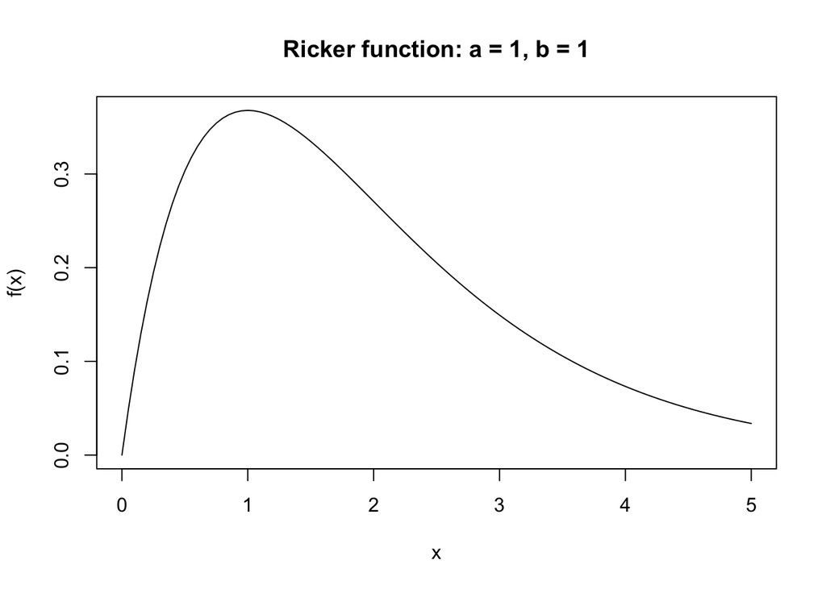

```r
ricker_fun = function(x, a, b)
{
  return(a * x * exp(-b * x))
}

curve(
  ricker_fun(x, 1, 1),
  from = 0, to = 5, add = FALSE,
  main = "Ricker function: a = 1, b = 1",
  ylab = "f(x)", xlab = "x")
```

# Create an exponential function

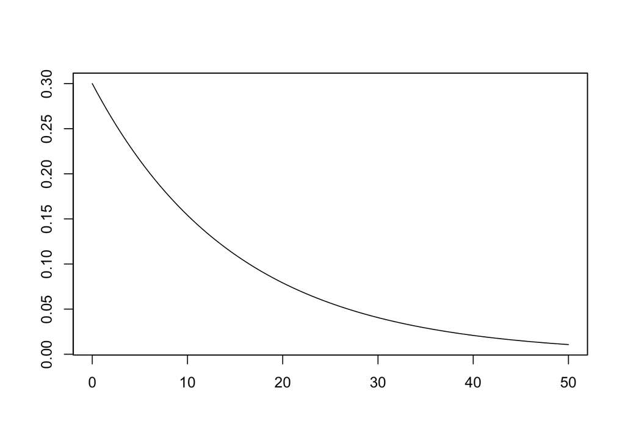

```r
exp_fun = function(x, a, b)
{
  return(a * exp(-b * x))
}

curve(
  exp_fun(x, 0.3, 1/15), add = FALSE, from = 0,
  to = 50,
  ann = FALSE, axes = TRUE, ylab = "f(x)");
  box()
```

# Simulated data on a line

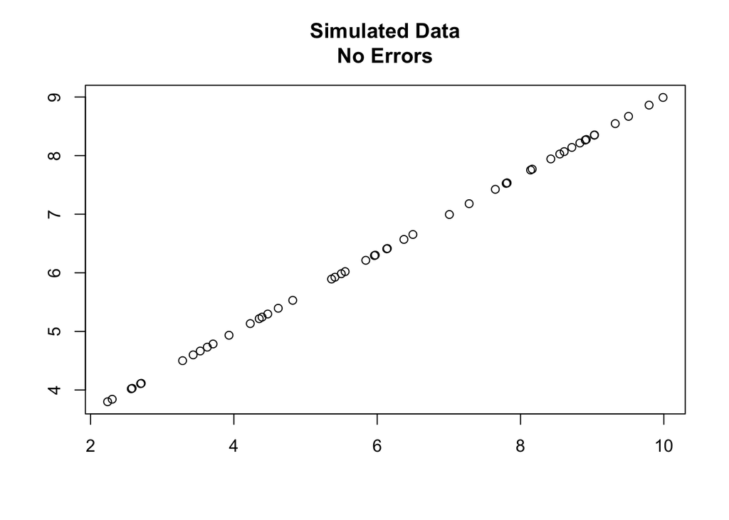

```r
# Seed the RNG so we can reproduce our results
set.seed(1234567)

# Specify the x-range and number of points:
n_pts = 50
x_min = 2
x_max = 10

# Generate the x-values
x_sim = runif(n_pts, min = x_min, max = x_max)

# Choose an intercept and slope for our deterministic model and generate the ‘predicted’ y values
param_intercept = 2.3
param_slope = 0.67
y_pred = param_intercept + x_sim * param_slope
plot(x_sim, y_pred, main = "Simulated Data\nNo Errors", xlab = "", ylab = "")
```

# Normal errors 1

# Add some normally-distributed noise to generate our ‘observed’ y-values

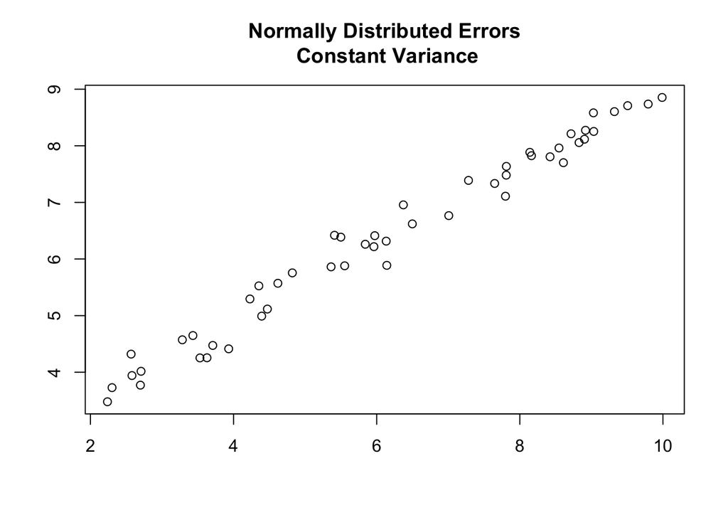

```r
error_mean = 0
error_sd = 0.25

y_observed =
  y_pred +
  rnorm(
    n = n_pts,
    mean = error_mean,
    sd = error_sd)
plot(x_sim, y_observed, main = "Normally Distributed Errors\n Constant Variance", xlab = "", ylab = "")
```

# Normal errors 2

# To use a more sophisticated stochastic model, we can make the variability larger with increasing values of x

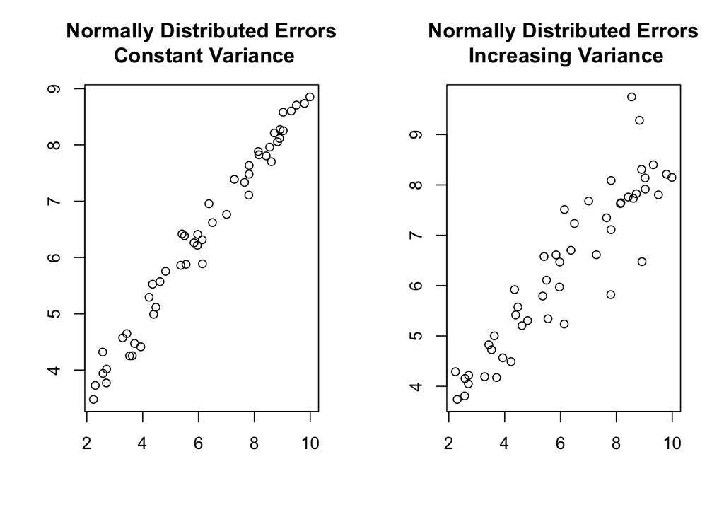

```r
error_mean = 0
error_sd = 0.1

y_observed_2 =
  y_pred +
  rnorm(
    n = n_pts,
    mean = error_mean,
    sd = error_sd * x_sim)

par(mfrow = c(1, 2))
plot(x_sim, y_observed, main = "Normally Distributed Errors\n Constant Variance", xlab = "", ylab = "")
plot(x_sim, y_observed_2, main = "Normally Distributed Errors\n Increasing Variance", xlab = "", ylab = "")
```

# Choosing a model

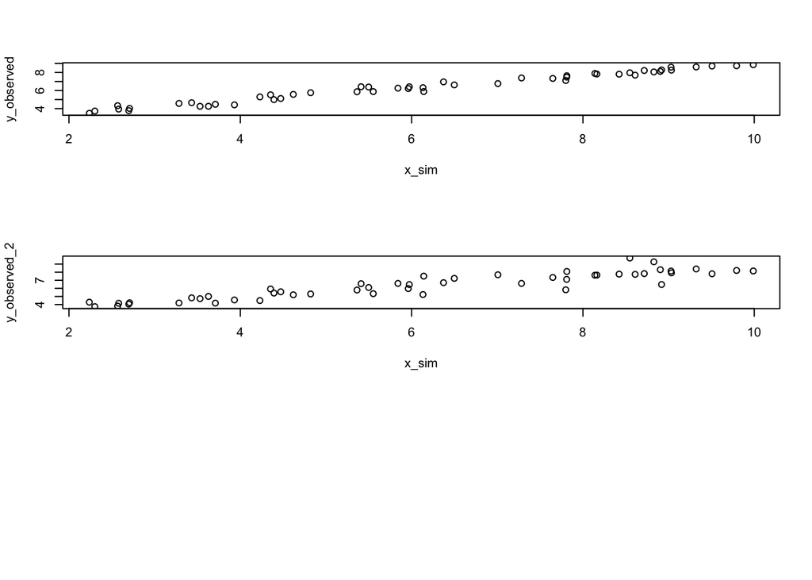

```r
par(mfrow = c(3, 1))
plot(x_sim, y_observed)
plot(x_sim, y_observed_2)

par(mfrow = c(3, 1))
```

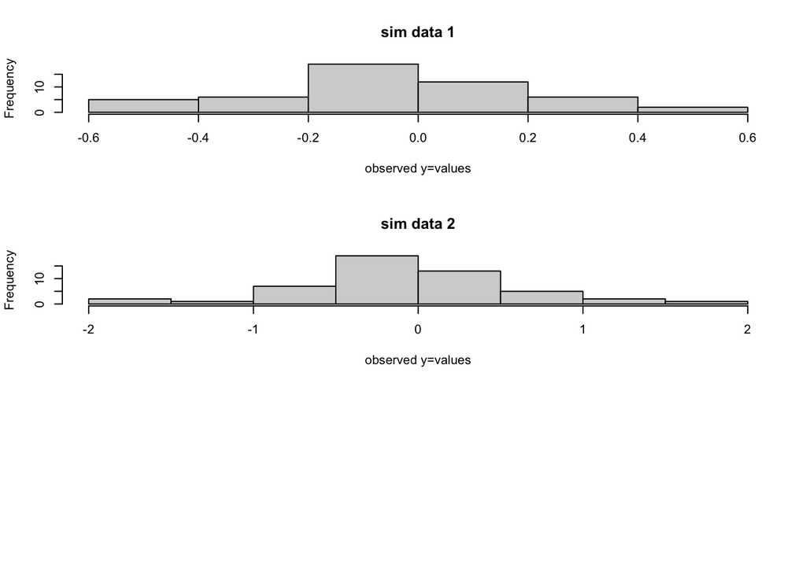

```r
hist(y_observed - y_pred, main = "sim data 1", xlab = "observed y=values")
hist(y_observed_2 - y_pred, main = "sim data 2", xlab = "observed y=values")
```

# Lab 5

```r
# Load the data into a dataframe
require(here)
dat_dispersal = data.frame(read.csv(here("data", "dispersal.csv")))
head(dat_dispersal)
```

```
##   dist.class disp.rate.ftb disp.rate.eb
## 1        100          0.00          0.0
## 2        200          0.25          0.8
## 3        300          0.65          0.2
## 4        400          0.92          0.1
## 5        500          0.40          0.3
## 6        600          0.00          0.0
```

# Question 1

```r
exp_fun = function(x, a, b)
{
  return(a * exp(-b * x))
}
```

# Question 2

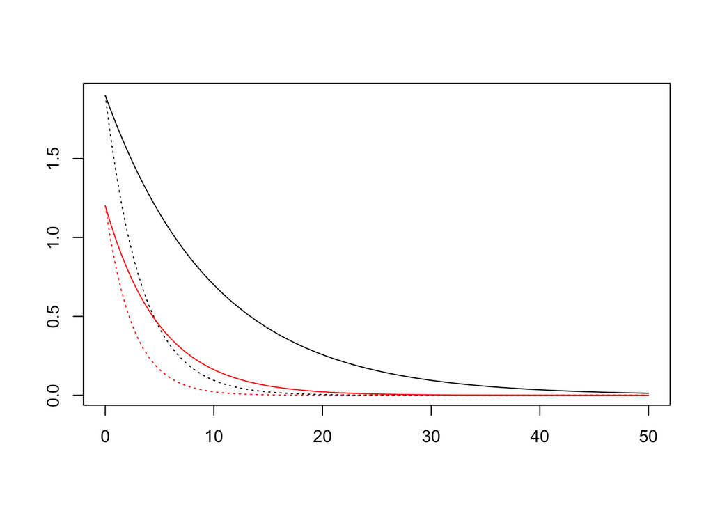

```r
{
  curve(
    exp_fun(x, 1.9, 0.1), add = FALSE, from = 0,
    to = 50,
    ann = FALSE, axes = TRUE, col = "black", lty = "solid",
    ylab = "f(x)"); box()
  curve(
    exp_fun(x, 1.9, 0.3), add = TRUE, col = "black", lty = "dotted")
  curve(
    exp_fun(x, 1.2, 0.2), add = TRUE, col = "red", lty = "solid")
  curve(
    exp_fun(x, 1.2, 0.4), add = TRUE,  col = "red", lty = "dotted")
}
```

# Question 3

When I change parameter a, it seems to change the height of where the curve starts. The red lines have lower a values and they start much lower on the y-axis than where the black lines start.

# Question 4

# Question 5

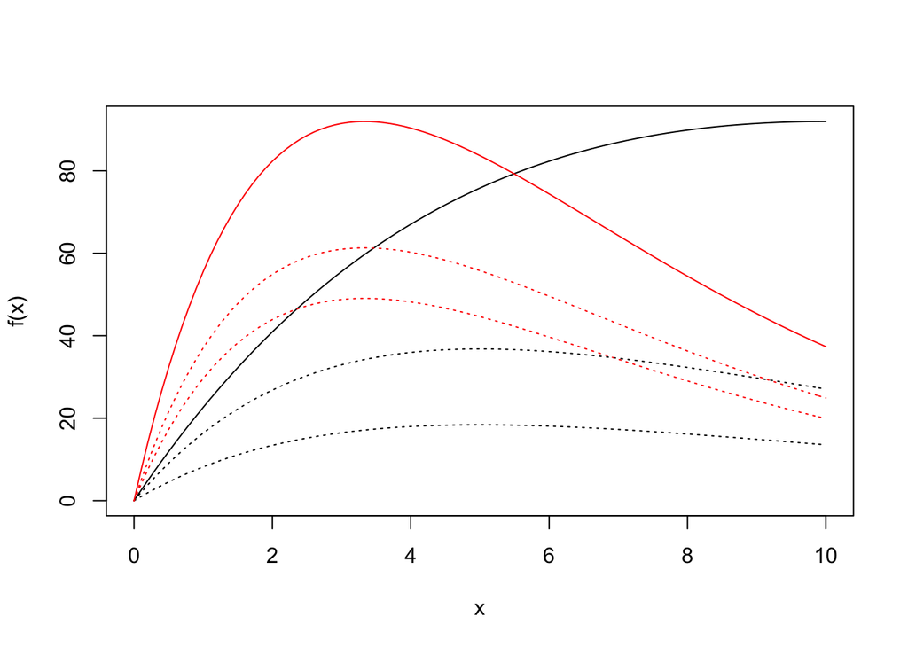

```r
{
  curve(
    ricker_fun(x, 25, 0.1),
    from = 0, to = 10, add = FALSE, col = "black", lty = "solid",
    ylab = "f(x)", xlab = "x")
  curve(
    ricker_fun(x, 20, 0.2),
    add = TRUE, col = "black", lty = "dotted")
  curve(
    ricker_fun(x, 10, 0.2),
    add = TRUE, col = "black", lty = "dotted")
  curve(
    ricker_fun(x, 75, 0.3),
    add = TRUE, col = "red", lty = "solid")
  curve(
    ricker_fun(x, 50, 0.3),
    add = TRUE, col = "red", lty = "dotted")
  curve(
    ricker_fun(x, 40, 0.3),
    add = TRUE, col = "red", lty = "dotted")
}
```

# Question 6

Varying the a parameter seems to change the height of the curve. The lines with higher a values have higher peaks than the lines with lower a values.

# Question 7

# Question 8

My intercept values are x = 1465 and y = 0.05. My slope value is -0.0003.

I chose the values of my intercept parameters by using locator(1) that was suggested in the instructions. I chose my slope value by trying out many different values and essentially guessing until I found a slope that I thought fit the model well.

# Question 9

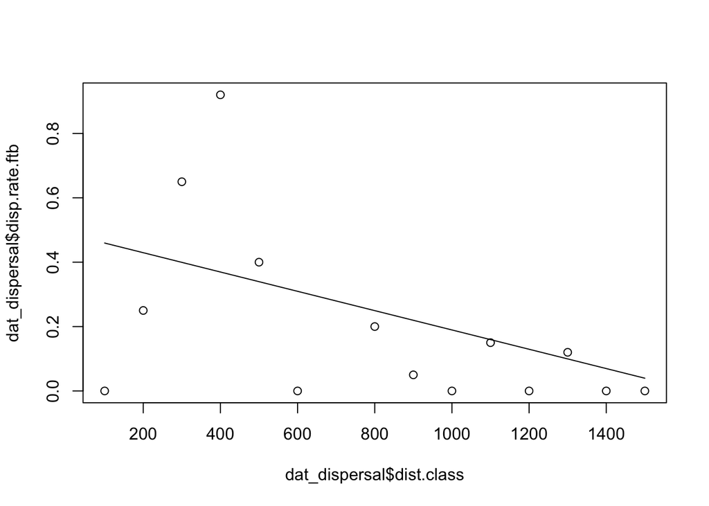

```r
line_point_slope = function(x, x1, y1, slope)
  {
    get_y_intercept =
      function(x1, y1, slope)
        return(-(x1 * slope) + y1)

    linear =
      function(x, yint, slope)
        return(yint + x * slope)

    return(linear(x, get_y_intercept(x1, y1, slope), slope))
  }

guess_x = 1465
guess_y = 0.05
guess_slope = -0.0003

plot(x = dat_dispersal$dist.class, y = dat_dispersal$disp.rate.ftb)
curve(line_point_slope(x, guess_x, guess_y, guess_slope), add = T)
```

```r
dat_dispersal$predicted_lin = line_point_slope(dat_dispersal$dist.class, guess_x, guess_y, guess_slope)
```

# Question 10

My values are a = 1 and b = 0.0033. I set my a value as 1 becuase I wanted the function to start at the beginning of the x scale, and I essentially guessed for the b value by putting it lots of numberrs until I came up with a good visual fit.

# Question 11

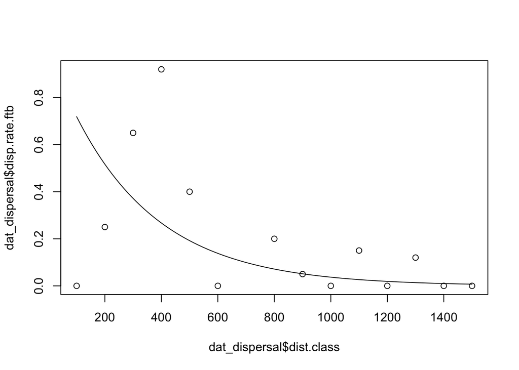

```r
plot(x = dat_dispersal$dist.class, y = dat_dispersal$disp.rate.ftb)
curve(
    exp_fun(x, 1, 0.0033), add = TRUE)
```

```r
dat_dispersal$predicted_exp = exp_fun(dat_dispersal$dist.class, 1, 0.0033)
```

# Question 12

My values are a = 0.007 and b = 0.0037. I started with 1/400 for both values and then adjusted the values incrementally from there until I got a good visual fit.

# Question 13

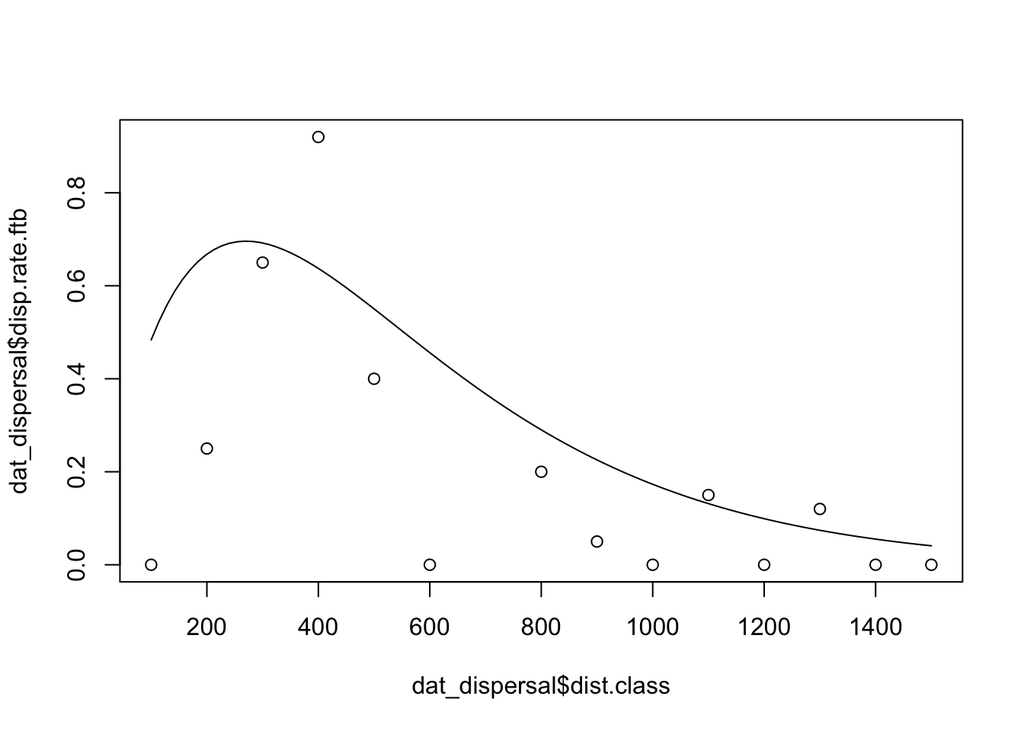

```r
plot(x = dat_dispersal$dist.class, y = dat_dispersal$disp.rate.ftb)
curve(
    ricker_fun(x, 0.007, 0.0037), add = TRUE)
```

```r
dat_dispersal$predicted_rick = ricker_fun(dat_dispersal$dist.class, 0.007, 0.0037)
```

# Question 14

```r
dat_dispersal$resids_linear = (dat_dispersal$disp.rate.ftb - dat_dispersal$predicted_lin)

dat_dispersal$resids_exp = (dat_dispersal$disp.rate.ftb - dat_dispersal$predicted_exp)

dat_dispersal$resids_ricker = (dat_dispersal$disp.rate.ftb - dat_dispersal$predicted_rick)

head(dat_dispersal)
```

```
##   dist.class disp.rate.ftb disp.rate.eb predicted_lin predicted_exp
## 1        100          0.00          0.0        0.4595     0.7189237
## 2        200          0.25          0.8        0.4295     0.5168513
## 3        300          0.65          0.2        0.3995     0.3715767
## 4        400          0.92          0.1        0.3695     0.2671353
## 5        500          0.40          0.3        0.3395     0.1920499
## 6        600          0.00          0.0        0.3095     0.1380692
##   predicted_rick resids_linear resids_exp resids_ricker
## 1      0.4835140       -0.4595 -0.7189237   -0.48351403
## 2      0.6679595       -0.1795 -0.2668513   -0.41795948
## 3      0.6920738        0.2505  0.2784233   -0.04207382
## 4      0.6373855        0.5505  0.6528647    0.28261447
## 5      0.5503301        0.0605  0.2079501   -0.15033008
## 6      0.4561583       -0.3095 -0.1380692   -0.45615826
```

# Question 15

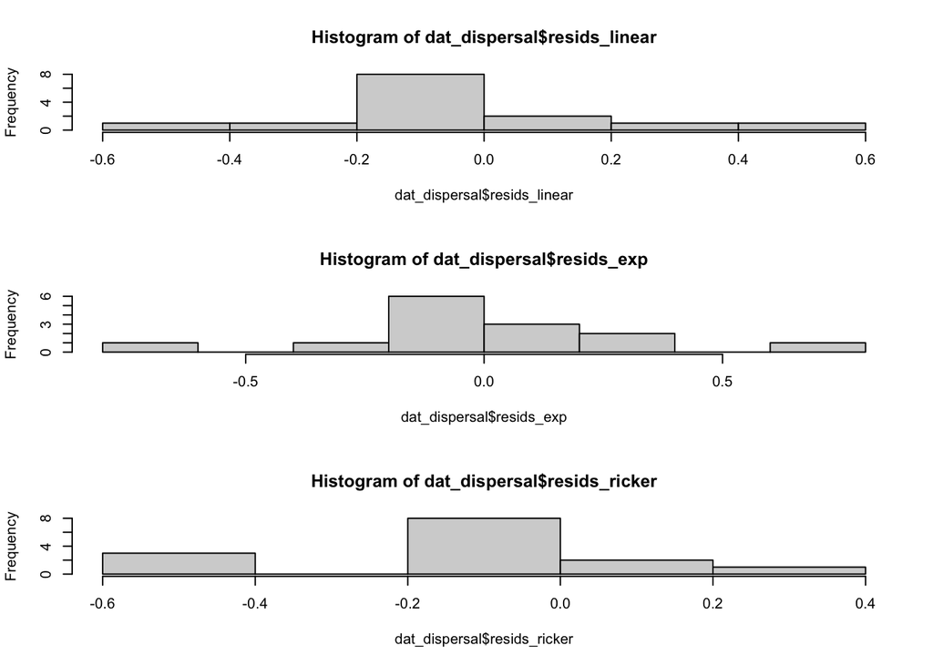

```r
par(mfrow = c(3, 1))

hist(dat_dispersal$resids_linear)
hist(dat_dispersal$resids_exp)
hist(dat_dispersal$resids_ricker)
```